# EDA and Data cleanup

David Crook

November 5, 2015

View output EDA.html.

## Setup

```r
setwd("~/projects/Classes/FoundationsOfDataScience_sliderule/github/capstone/GiveMeSomeCredit")

suppressMessages(library(dplyr)) # summarise
library(mice)
library(caret)
# library(psych)  # includes describe()

library(data.table)
library(FSelector)
library(ggplot2)

library(gridExtra)
```

## Start exploring the data set

```r
cs <- read.csv("cs-training.csv")

str(cs)
```

```
## 'data.frame':    150000 obs. of  12 variables:
##  $ X                                   : int  1 2 3 4 5 6 7 8 9 10 ...
##  $ SeriousDlqin2yrs                    : int  1 0 0 0 0 0 0 0 0 0 ...
##  $ RevolvingUtilizationOfUnsecuredLines: num  0.766 0.957 0.658 0.234 0.907 ...
##  $ age                                 : int  45 40 38 30 49 74 57 39 27 57 ...
##  $ NumberOfTime30.59DaysPastDueNotWorse: int  2 0 1 0 1 0 0 0 0 0 ...
##  $ DebtRatio                           : num  0.803 0.1219 0.0851 0.036 0.0249 ...
##  $ MonthlyIncome                       : int  9120 2600 3042 3300 63588 3500 NA 3500 NA 23684 ...
##  $ NumberOfOpenCreditLinesAndLoans     : int  13 4 2 5 7 3 8 8 2 9 ...
##  $ NumberOfTimes90DaysLate             : int  0 0 1 0 0 0 0 0 0 0 ...
##  $ NumberRealEstateLoansOrLines        : int  6 0 0 0 1 1 3 0 0 4 ...
##  $ NumberOfTime60.89DaysPastDueNotWorse: int  0 0 0 0 0 0 0 0 0 0 ...
##  $ NumberOfDependents                  : int  2 1 0 0 0 1 0 0 NA 2 ...
```

```r
# can drop the 'X' column, as it is just the observation number in sequence

# Gets rid of the "X" column
cs <- rbind(cs)[ , -1]

# convert SeriousDlqin2yrs to a factor
cs$SeriousDlqin2yrs <- factor(cs$SeriousDlqin2yrs,
                              levels = c(0, 1), labels = c("ok", "delinquent"))

nb_samples <- nrow(cs)
```

Out of the **150,000** samples, the rate of delinquency is **6.68%** (**10,026** observations).

### Demographics

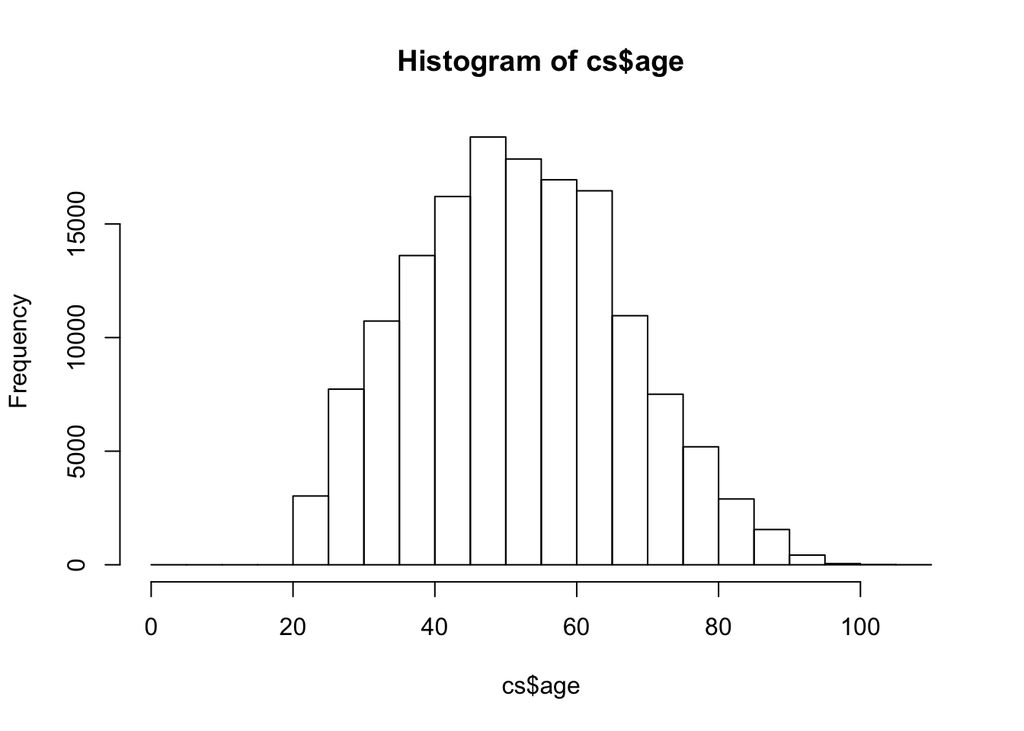

One of the ages is 0 - impute? or drop?

```r
table(cs$NumberOfDependents)
```

```
##
##     0     1     2     3     4     5     6     7     8     9    10    13
## 86902 26316 19522  9483  2862   746   158    51    24     5     5     1
##    20
##     1
```

There are a couple of suspect outliers (>10) but not too bad.

### Finances

#### DebtRatio

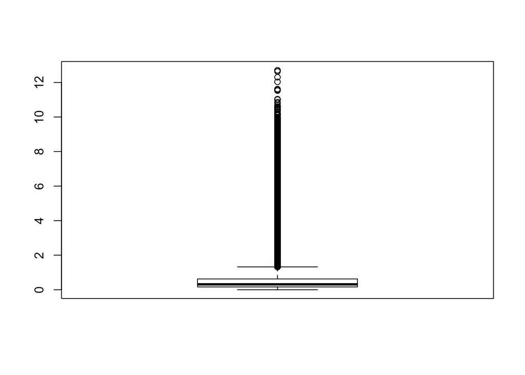

```r
#boxplot(cs$DebtRatio)
boxplot(log(cs$DebtRatio + 1))
```

There are many outliers in this variable, with a median of **0.37** and a mean of **353.01**

#### MonthlyIncome

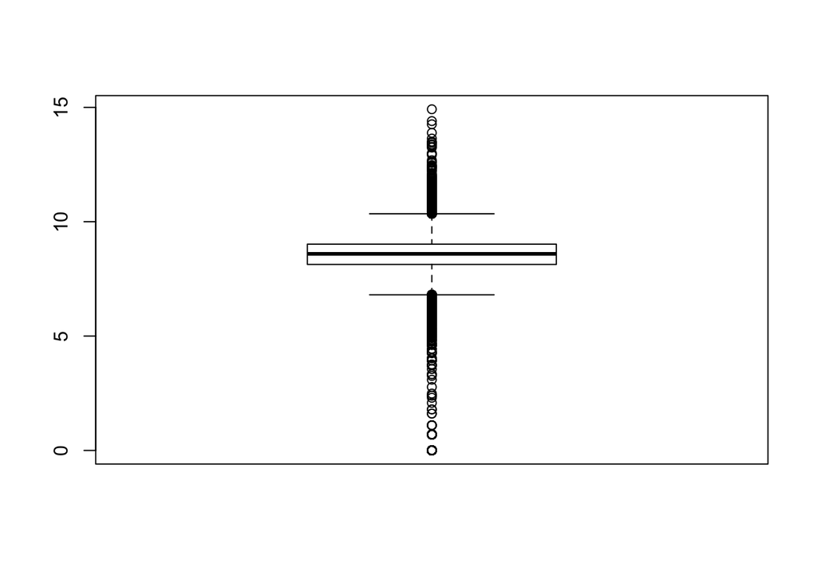

```r
### boxplot(cs$MonthlyIncome)
boxplot(log(cs$MonthlyIncome + 1))
```

```r
summary(log(cs$MonthlyIncome + 1))
```

```
##    Min. 1st Qu.  Median    Mean 3rd Qu.    Max.    NA's
##   0.000   8.132   8.594   8.411   9.018  14.920   29731
```

There are **29,731 NA**s in `MonthlyIncome`.

#### Creating additional Finances variables

```r
# https://www.kaggle.com/c/GiveMeSomeCredit/forums/t/1166/congratulations-to-the-winners/7231#post7231
# "DebtRatio was computed by substituting 1 to MonthlyIncome, where
# MonthlyIncome was not available"

# create a derived variable called MonthlyExpenses taking the above NA
# disposition into account
cs$MonthlyExpenses <- ifelse(is.na(cs$MonthlyIncome),
                             1 * cs$DebtRatio,
                             cs$MonthlyIncome * cs$DebtRatio)

# create another derived variable called NetMonthlySurplus
cs$NetMonthlySurplus <- ifelse(is.na(cs$MonthlyIncome),
                             0 - cs$MonthlyExpenses,
                             cs$MonthlyIncome - cs$MonthlyExpenses)
```

Some boxplots for these created variables:

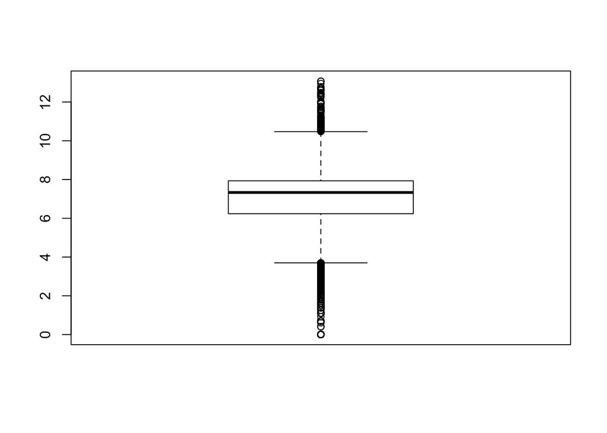

```r
boxplot(log(1 + cs$MonthlyExpenses))
```

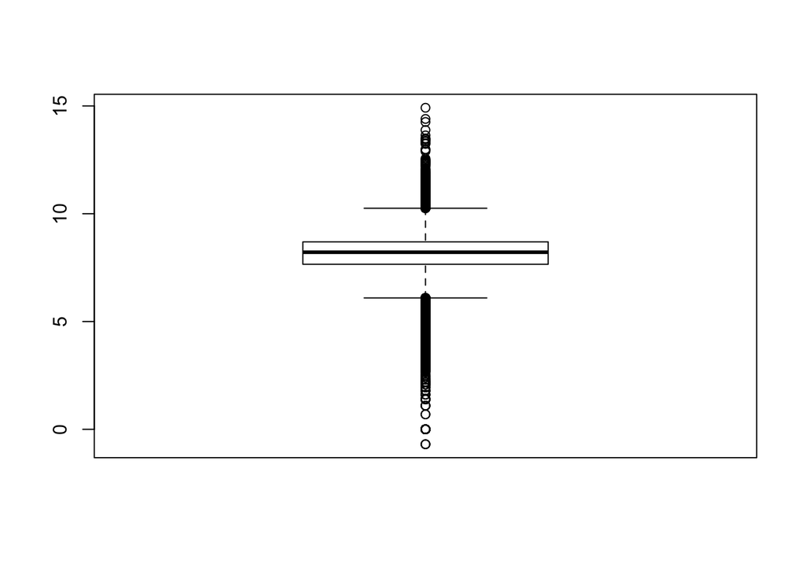

```r
boxplot(log(cs$NetMonthlySurplus))
```

**32,783** have `MonthlyExpenses` equalling `DebtRatio`, and **37,138** have `NetMonthlySurplus` of less than/equal to `1`

```r
table(cs$SeriousDlqin2yrs, cs$NetMonthlySurplus <= 1)
```

```
##
##               FALSE   TRUE
##   ok         105248  34726
##   delinquent   7614   2412
```

The **sensitivity** for primitive predictor `cs$NetMonthlySurplus <= 1` is **24.06%**, and the **specificity** is **75.19%**.

For our model, we want a higher sensitivity than that to predict a much higher portion of the delinquent borrowers, since these are the costly borrowers.

### Deliquencies

```r
#table(cs$NumberOfTime30.59DaysPastDueNotWorse)
#table(cs$NumberOfTime60.89DaysPastDueNotWorse)
#table(cs$NumberOfTimes90DaysLate)

# there are 5 times of 96 and 264 times of 98 in each of these
# these are nonsensical values, and will be converted to NA

cs$NumberOfTime30.59DaysPastDueNotWorse <- ifelse(cs$NumberOfTime30.59DaysPastDueNotWorse >= 96, NA,
                                                  cs$NumberOfTime30.59DaysPastDueNotWorse)

cs$NumberOfTime60.89DaysPastDueNotWorse <- ifelse(cs$NumberOfTime60.89DaysPastDueNotWorse >= 96, NA,
                                                  cs$NumberOfTime60.89DaysPastDueNotWorse)

cs$NumberOfTimes90DaysLate <- ifelse(cs$NumberOfTimes90DaysLate >= 96, NA,
                                     cs$NumberOfTimes90DaysLate)

# perhaps we'll impute these or perhaps we'll leave them
```

#### Creating additional Deliquencies variables

The Delinquencies variables are all related. Let’s try to consolidate to a single new variable.

```r
cs$ConsolidatedNumberOfDaysPastDue <- (cs$NumberOfTime30.59DaysPastDueNotWorse * 30) +
  (cs$NumberOfTime60.89DaysPastDueNotWorse * 60) +
  (cs$NumberOfTimes90DaysLate * 90)

# the following is just to demonstrate that >90 days in the data is not a subset
# of >60, and the calculation above is valid
t1 <- subset(cs, ConsolidatedNumberOfDaysPastDue > 0)
t1[2,c("NumberOfTime30.59DaysPastDueNotWorse", "NumberOfTime60.89DaysPastDueNotWorse", "NumberOfTimes90DaysLate", "ConsolidatedNumberOfDaysPastDue")]
```

```
##   NumberOfTime30.59DaysPastDueNotWorse
## 3                                    1
##   NumberOfTime60.89DaysPastDueNotWorse NumberOfTimes90DaysLate
## 3                                    0                       1
##   ConsolidatedNumberOfDaysPastDue
## 3                             120
```

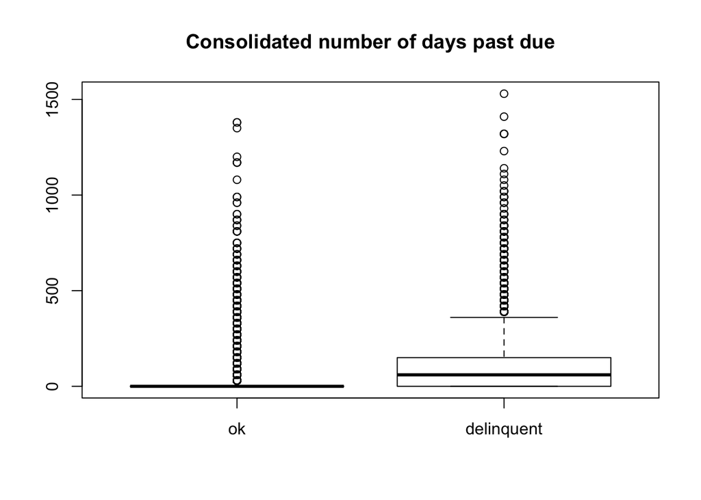

```r
#table(cs$ConsolidatedNumberOfDaysPastDue)
boxplot(ConsolidatedNumberOfDaysPastDue ~ SeriousDlqin2yrs, data = cs,
        main = "Consolidated number of days past due")
```

The boxplot shows a positive correlation for delinquencies.

### Existing Credit Utilization

```r
### Existing Credit Utilization

# a few of these seem unrealistically high. are they accurate?
#table(cs$NumberRealEstateLoansOrLines)
summary(cs$NumberRealEstateLoansOrLines)
```

```
##    Min. 1st Qu.  Median    Mean 3rd Qu.    Max.
##   0.000   0.000   1.000   1.018   2.000  54.000
```

```r
#table(cs$NumberOfOpenCreditLinesAndLoans)
summary(cs$NumberOfOpenCreditLinesAndLoans)
```

```
##    Min. 1st Qu.  Median    Mean 3rd Qu.    Max.
##   0.000   5.000   8.000   8.453  11.000  58.000
```

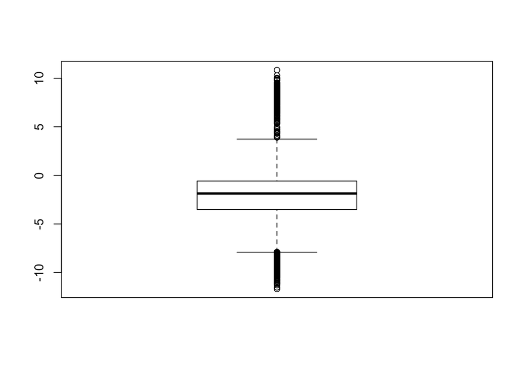

```r
# some serious outliers in this variable, perhaps cutoff / normalize
boxplot(log(cs$RevolvingUtilizationOfUnsecuredLines))
```

## Additional data cleanup

### zero age and NAs in MonthlyIncome, NumberOfDependents

One of the `age` observations is 0. let’s impute this observation, along with `MonthlyIncome` and `NumberOfDependents` **NA**s.

```r
cs$age <- ifelse(cs$age == 0, NA, cs$age)
sum(is.na(cs$age))
```

```
## [1] 1
```

```r
set.seed(144)

# Multiple imputation
simplified = cs[c("age", "DebtRatio", "MonthlyIncome", "NumberOfDependents", "SeriousDlqin2yrs",
  "NumberRealEstateLoansOrLines", "NumberOfOpenCreditLinesAndLoans"
  )]

### This takes a long time so save the results
##imputed = complete(mice(simplified))
##save(imputed,file="imputed_simplified.Rda")
load("imputed_simplified.Rda")  # load value in R object 'imputed'
```

Here is what the imputed values look like:

```r
# age
imputed[rownames(subset(cs, is.na(cs$age))),]$age
```

```
## [1] 40
```

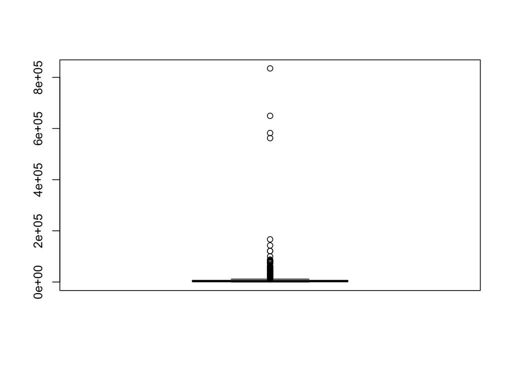

```r
# MonthlyIncome and NumberOfDependents imputed value summaries
imputed.mi <- imputed[rownames(subset(cs, is.na(cs$MonthlyIncome))),]$MonthlyIncome
imputed.nd <- imputed[rownames(subset(cs, is.na(cs$NumberOfDependents))),]$NumberOfDependents
#describe(imputed.mi)
boxplot(imputed.mi)
```

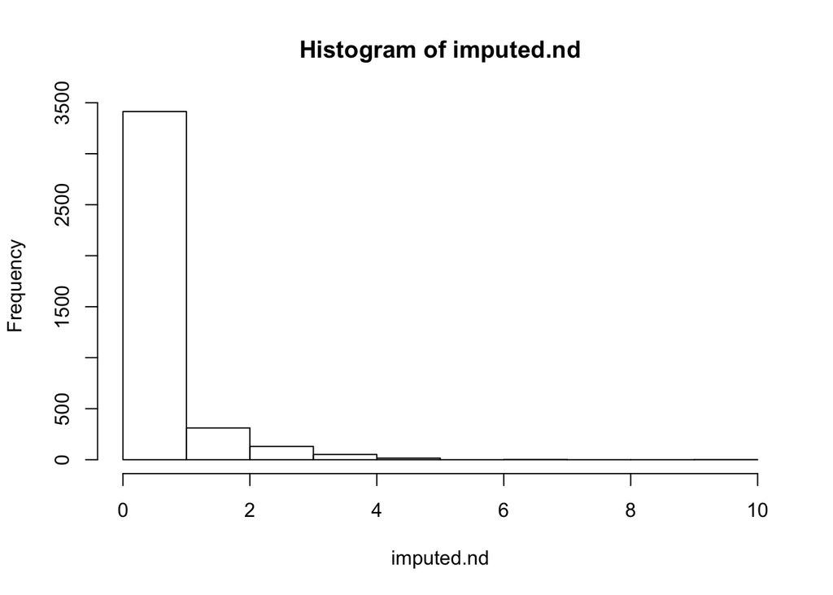

```r
#describe(imputed.nd)
hist(imputed.nd)
```

Save the imputed values back to main dataframe

```r
cs$age <- imputed$age
cs$MonthlyIncome <- imputed$MonthlyIncome
cs$NumberOfDependents <- imputed$NumberOfDependents
```

### Delinquency NAs

For logisitic regression, we would like all our data to have no **NA**s, so will convert **NAs** in the delinquency fields to their respective *median* value, which in all cases is zero.

```r
m30 <- median(cs$NumberOfTime30.59DaysPastDueNotWorse, na.rm = TRUE)
m60 <- median(cs$NumberOfTime60.89DaysPastDueNotWorse, na.rm = TRUE)
m90 <- median(cs$NumberOfTimes90DaysLate, na.rm = TRUE)
mCons <- median(cs$ConsolidatedNumberOfDaysPastDue, na.rm = TRUE)

cs$NumberOfTime30.59DaysPastDueNotWorse <- ifelse(is.na(cs$NumberOfTime30.59DaysPastDueNotWorse),
                                                  m30,
                                                  cs$NumberOfTime30.59DaysPastDueNotWorse)

cs$NumberOfTime60.89DaysPastDueNotWorse <- ifelse(is.na(cs$NumberOfTime60.89DaysPastDueNotWorse),
                                                  m60,
                                                  cs$NumberOfTime60.89DaysPastDueNotWorse)

cs$NumberOfTimes90DaysLate <- ifelse(is.na(cs$NumberOfTimes90DaysLate),
                                     m90,
                                     cs$NumberOfTimes90DaysLate)

cs$ConsolidatedNumberOfDaysPastDue <- ifelse(is.na(cs$ConsolidatedNumberOfDaysPastDue),
                                             mCons,
                                             cs$ConsolidatedNumberOfDaysPastDue)
```

## Save cleaned version of data

```r
# summary(cs)

# convert back to integer before saving
seriousd.int <- as.integer(factor(cs$SeriousDlqin2yrs))
seriousd.int <- ifelse(seriousd.int == 2, 1, 0)
cs$SeriousDlqin2yrs <- (seriousd.int)

write.table(cs, "cs-training-cleaned.csv", quote=F, row.names=F, sep=",")
```

# Feature selection

Added use of `FSelector` package based on mentor feedback.

Had to spend a few hours [getting FSelector package installed on my system](http://github.crookster.org/RStudio-and-rJava-on-OS-X-El-Capitan/).

## `information.gain()` in `FSelector`

```r
original_feature_weights <- information.gain(SeriousDlqin2yrs ~
                                               NumberOfDependents +
                                               NumberRealEstateLoansOrLines +
                                               MonthlyIncome +
                                               DebtRatio +
                                               NumberOfOpenCreditLinesAndLoans +
                                               age +
                                               NumberOfTime60.89DaysPastDueNotWorse +
                                               NumberOfTime30.59DaysPastDueNotWorse +
                                               NumberOfTimes90DaysLate +
                                               RevolvingUtilizationOfUnsecuredLines, cs)

# Scale and order features
scale_factor = sum(original_feature_weights$attr_importance)
scaled_feature_weights <- original_feature_weights * (100 / scale_factor)
setorder(scaled_feature_weights, attr_importance)
feature_names <- row.names(scaled_feature_weights)

# Took me an hour of screwing around to figure out how to have labels not get
# truncated in the plot.  Turned out you must set the mar par param with par;
# cannot be set in barplot()!! and you must set par after png()

#par(mar = c(5, 4, 4, 2) + 0.1)
png("original_varImpFSelector.png", width=8, height=6, units="in", res=100)
par(mar = c(5, 20, 4, 2) + 0.1)
barplot(scaled_feature_weights$attr_importance,
        names.arg = feature_names,
        horiz = TRUE, las = 1,
        xlab = "Scaled relative feature importance",
        main = "Original Feature Importance from information.gain()            ."
        )
dev.off()
```

```r
feature_weights <- information.gain(SeriousDlqin2yrs ~
                                      NumberOfDependents +
                                      NumberRealEstateLoansOrLines +
                                      MonthlyIncome +
                                      NumberOfOpenCreditLinesAndLoans +
                                      age +
                                      MonthlyExpenses +
                                      NetMonthlySurplus +
#                                       NumberOfTime60.89DaysPastDueNotWorse +
#                                       NumberOfTime30.59DaysPastDueNotWorse +
#                                       NumberOfTimes90DaysLate +
                                      ConsolidatedNumberOfDaysPastDue +
                                      RevolvingUtilizationOfUnsecuredLines, cs)
print(feature_weights)
```

```
##                                      attr_importance
## NumberOfDependents                      0.0002863713
## NumberRealEstateLoansOrLines            0.0006043086
## MonthlyIncome                           0.0005528109
## NumberOfOpenCreditLinesAndLoans         0.0010893387
## age                                     0.0019202191
## MonthlyExpenses                         0.0002244544
## NetMonthlySurplus                       0.0005476050
## ConsolidatedNumberOfDaysPastDue         0.0198172721
## RevolvingUtilizationOfUnsecuredLines    0.0111463670
```

```r
# Scale and order features
scale_factor = sum(feature_weights$attr_importance)
scaled_feature_weights <- feature_weights * (100 / scale_factor)
setorder(scaled_feature_weights, attr_importance)
feature_names <- row.names(scaled_feature_weights)

png("varImpFSelector.png", width=8, height=6, units="in", res=100)
par(mar = c(5, 20, 4, 2) + 0.1)
barplot(scaled_feature_weights$attr_importance,
        names.arg = feature_names,
        horiz = TRUE, las = 1,
        xlab = "Scaled relative feature importance",
        main = "2nd Iteration Feat. Import. from information.gain()"
        )
dev.off()
```

```r
# get a formula for the top features
subset_features <- cutoff.k(feature_weights, 6)
f <- as.simple.formula(subset_features, "SeriousDlqin2yrs")
print(f)
```

[output not shown]

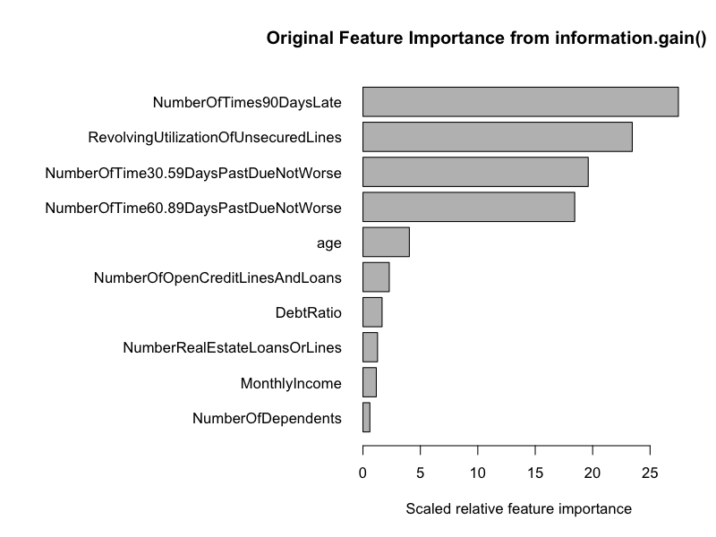

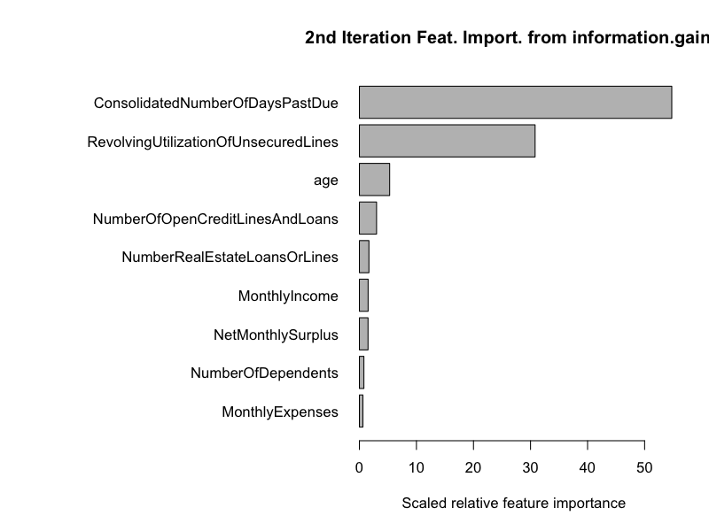

### Some feature EDA

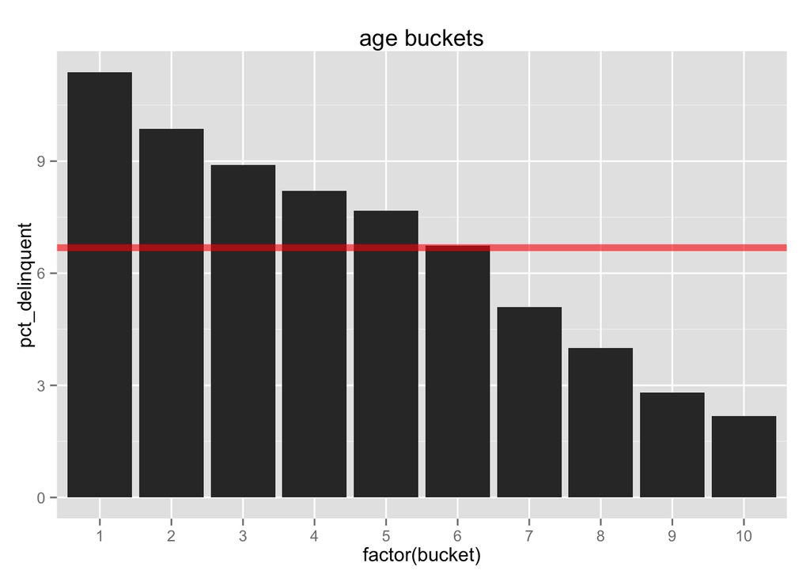

```r
sample_avg = mean(cs$SeriousDlqin2yrs)
########################################
#  age
########################################

# generated with gen_feature_bucket_r.py

# split into ten groups based on age
num_buckets <- 10
bucket <- seq(1, num_buckets)
ar <- rank(cs$age, ties.method = "first")
decile <- cut(ar, quantile(ar, probs=0:10/10), include.lowest=TRUE, labels=FALSE)
deciles_age <- split(cs, decile)
pct_delinquent <- vector("numeric", length(deciles_age))
for (i in seq_along(deciles_age)){
  pct_delinquent[i] <- 100 * mean(deciles_age[[i]]$SeriousDlqin2yrs)
}
# results
D1 <- data.frame(pct_delinquent, bucket)
# str(D1)
p1 <- ggplot(data = D1, aes(x = factor(bucket), y = pct_delinquent)) +
  geom_bar(stat ="identity")  +
  geom_hline(aes (yintercept = 100 * sample_avg), alpha = 6/10, color = 'red', linetype = 1, lwd = 2) +
  ggtitle("age buckets")
p1
```

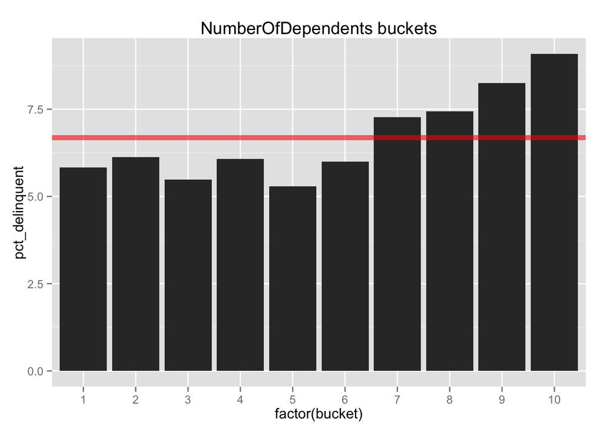

```r
########################################
#  NumberOfDependents
########################################

# generated with gen_feature_bucket_r.py

# split into ten groups based on age
num_buckets <- 10
bucket <- seq(1, num_buckets)
ar <- rank(cs$NumberOfDependents, ties.method = "first")
decile <- cut(ar, quantile(ar, probs=0:10/10), include.lowest=TRUE, labels=FALSE)
deciles_NumberOfDependents <- split(cs, decile)
pct_delinquent <- vector("numeric", length(deciles_NumberOfDependents))
for (i in seq_along(deciles_NumberOfDependents)){
  pct_delinquent[i] <- 100 * mean(deciles_NumberOfDependents[[i]]$SeriousDlqin2yrs)
}
# results
D2 <- data.frame(pct_delinquent, bucket)
# str(D2)
p2 <- ggplot(data = D2, aes(x = factor(bucket), y = pct_delinquent)) +
  geom_bar(stat ="identity")  +
  geom_hline(aes (yintercept = 100 * sample_avg), alpha = 6/10, color = 'red', linetype = 1, lwd = 2) +
  ggtitle("NumberOfDependents buckets")
p2
```

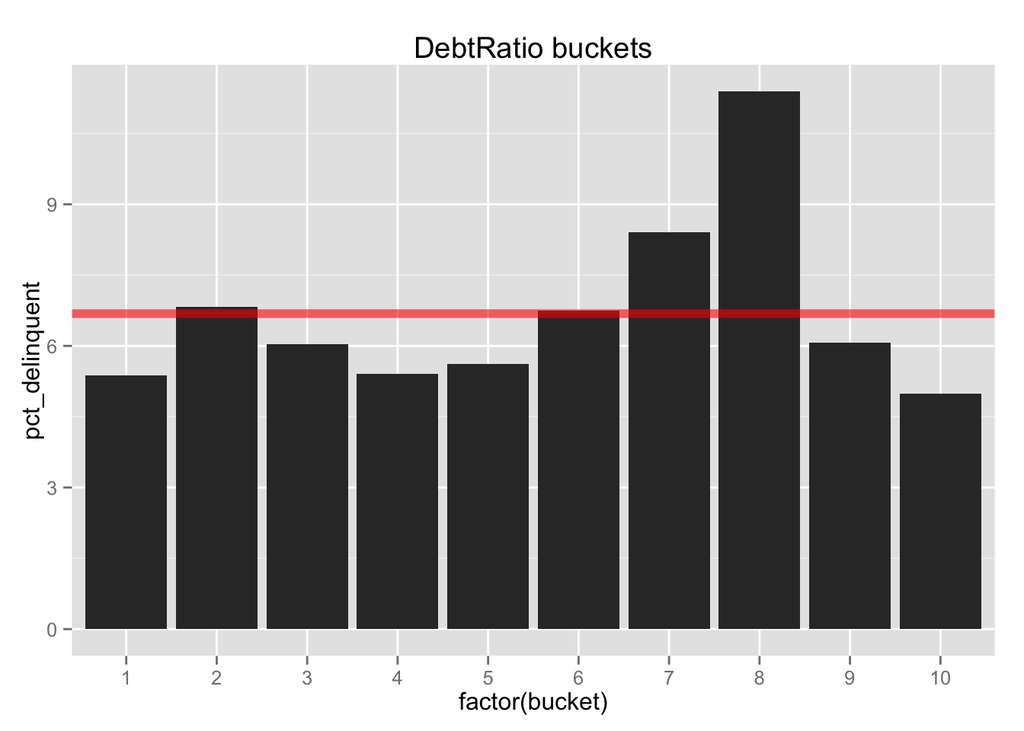

```r
########################################
#  DebtRatio
########################################

# generated with gen_feature_bucket_r.py

# split into ten groups based on age
num_buckets <- 10
bucket <- seq(1, num_buckets)
ar <- rank(cs$DebtRatio, ties.method = "first")
decile <- cut(ar, quantile(ar, probs=0:10/10), include.lowest=TRUE, labels=FALSE)
deciles_DebtRatio <- split(cs, decile)
pct_delinquent <- vector("numeric", length(deciles_DebtRatio))
for (i in seq_along(deciles_DebtRatio)){
  pct_delinquent[i] <- 100 * mean(deciles_DebtRatio[[i]]$SeriousDlqin2yrs)
}
# results
D3 <- data.frame(pct_delinquent, bucket)
# str(D3)
p3 <- ggplot(data = D3, aes(x = factor(bucket), y = pct_delinquent)) +
  geom_bar(stat ="identity")  +
  geom_hline(aes (yintercept = 100 * sample_avg), alpha = 6/10, color = 'red', linetype = 1, lwd = 2) +
  ggtitle("DebtRatio buckets")
p3
```

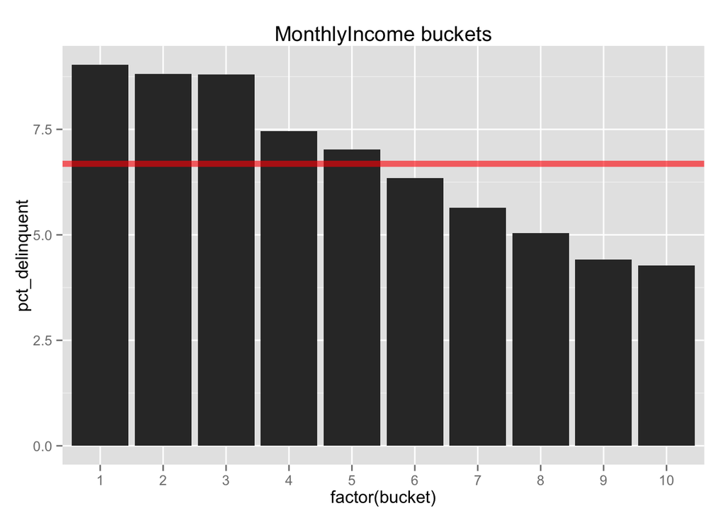

```r
########################################
#  MonthlyIncome
########################################

# generated with gen_feature_bucket_r.py

# split into ten groups based on age
num_buckets <- 10
bucket <- seq(1, num_buckets)
ar <- rank(cs$MonthlyIncome, ties.method = "first")
decile <- cut(ar, quantile(ar, probs=0:10/10), include.lowest=TRUE, labels=FALSE)
deciles_MonthlyIncome <- split(cs, decile)
pct_delinquent <- vector("numeric", length(deciles_MonthlyIncome))
for (i in seq_along(deciles_MonthlyIncome)){
  pct_delinquent[i] <- 100 * mean(deciles_MonthlyIncome[[i]]$SeriousDlqin2yrs)
}
# results
D4 <- data.frame(pct_delinquent, bucket)
# str(D4)
p4 <- ggplot(data = D4, aes(x = factor(bucket), y = pct_delinquent)) +
  geom_bar(stat ="identity")  +
  geom_hline(aes (yintercept = 100 * sample_avg), alpha = 6/10, color = 'red', linetype = 1, lwd = 2) +
  ggtitle("MonthlyIncome buckets")
p4
```

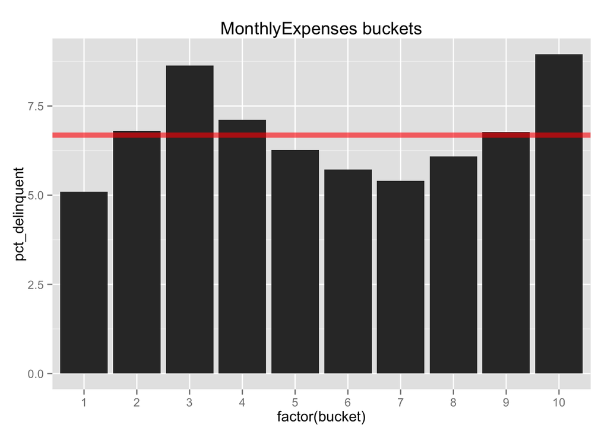

```r
########################################
#  MonthlyExpenses
########################################

# generated with gen_feature_bucket_r.py

# split into ten groups based on age
num_buckets <- 10
bucket <- seq(1, num_buckets)
ar <- rank(cs$MonthlyExpenses, ties.method = "first")
decile <- cut(ar, quantile(ar, probs=0:10/10), include.lowest=TRUE, labels=FALSE)
deciles_MonthlyExpenses <- split(cs, decile)
pct_delinquent <- vector("numeric", length(deciles_MonthlyExpenses))
for (i in seq_along(deciles_MonthlyExpenses)){
  pct_delinquent[i] <- 100 * mean(deciles_MonthlyExpenses[[i]]$SeriousDlqin2yrs)
}
# results
D5 <- data.frame(pct_delinquent, bucket)
# str(D5)
p5 <- ggplot(data = D5, aes(x = factor(bucket), y = pct_delinquent)) +
  geom_bar(stat ="identity")  +
  geom_hline(aes (yintercept = 100 * sample_avg), alpha = 6/10, color = 'red', linetype = 1, lwd = 2) +
  ggtitle("MonthlyExpenses buckets")
p5
```

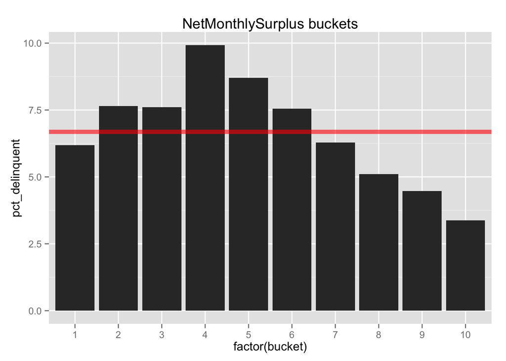

```r
########################################
#  NetMonthlySurplus
########################################

# generated with gen_feature_bucket_r.py

# split into ten groups based on age
num_buckets <- 10
bucket <- seq(1, num_buckets)
ar <- rank(cs$NetMonthlySurplus, ties.method = "first")
decile <- cut(ar, quantile(ar, probs=0:10/10), include.lowest=TRUE, labels=FALSE)
deciles_NetMonthlySurplus <- split(cs, decile)
pct_delinquent <- vector("numeric", length(deciles_NetMonthlySurplus))
for (i in seq_along(deciles_NetMonthlySurplus)){
  pct_delinquent[i] <- 100 * mean(deciles_NetMonthlySurplus[[i]]$SeriousDlqin2yrs)
}
# results
D6 <- data.frame(pct_delinquent, bucket)
# str(D6)
p6 <- ggplot(data = D6, aes(x = factor(bucket), y = pct_delinquent)) +
  geom_bar(stat ="identity")  +
  geom_hline(aes (yintercept = 100 * sample_avg), alpha = 6/10, color = 'red', linetype = 1, lwd = 2) +
  ggtitle("NetMonthlySurplus buckets")
p6
```

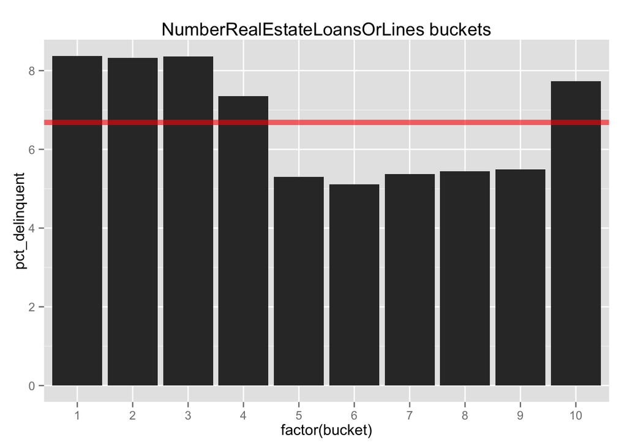

```r
########################################
#  NumberRealEstateLoansOrLines
########################################

# generated with gen_feature_bucket_r.py

# split into ten groups based on age
num_buckets <- 10
bucket <- seq(1, num_buckets)
ar <- rank(cs$NumberRealEstateLoansOrLines, ties.method = "first")
decile <- cut(ar, quantile(ar, probs=0:10/10), include.lowest=TRUE, labels=FALSE)
deciles_NumberRealEstateLoansOrLines <- split(cs, decile)
pct_delinquent <- vector("numeric", length(deciles_NumberRealEstateLoansOrLines))
for (i in seq_along(deciles_NumberRealEstateLoansOrLines)){
  pct_delinquent[i] <- 100 * mean(deciles_NumberRealEstateLoansOrLines[[i]]$SeriousDlqin2yrs)
}
# results
D7 <- data.frame(pct_delinquent, bucket)
# str(D7)
p7 <- ggplot(data = D7, aes(x = factor(bucket), y = pct_delinquent)) +
  geom_bar(stat ="identity")  +
  geom_hline(aes (yintercept = 100 * sample_avg), alpha = 6/10, color = 'red', linetype = 1, lwd = 2) +
  ggtitle("NumberRealEstateLoansOrLines buckets")
p7
```

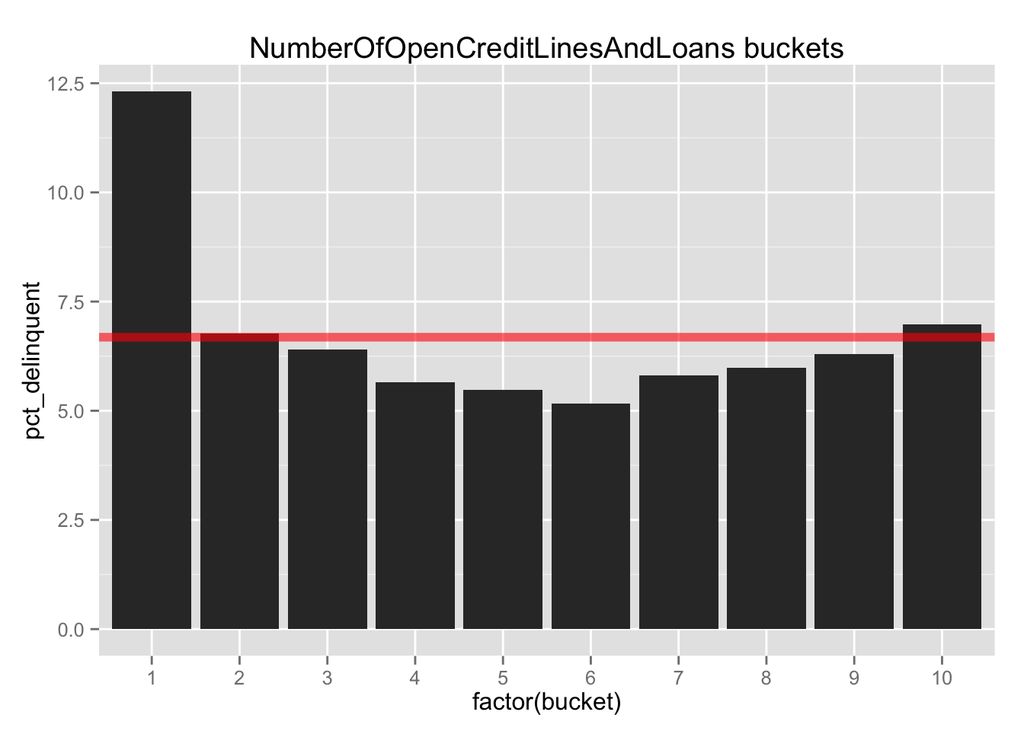

```r
########################################
#  NumberOfOpenCreditLinesAndLoans
########################################

# generated with gen_feature_bucket_r.py

# split into ten groups based on age
num_buckets <- 10
bucket <- seq(1, num_buckets)
ar <- rank(cs$NumberOfOpenCreditLinesAndLoans, ties.method = "first")
decile <- cut(ar, quantile(ar, probs=0:10/10), include.lowest=TRUE, labels=FALSE)
deciles_NumberOfOpenCreditLinesAndLoans <- split(cs, decile)
pct_delinquent <- vector("numeric", length(deciles_NumberOfOpenCreditLinesAndLoans))
for (i in seq_along(deciles_NumberOfOpenCreditLinesAndLoans)){
  pct_delinquent[i] <- 100 * mean(deciles_NumberOfOpenCreditLinesAndLoans[[i]]$SeriousDlqin2yrs)
}
# results
D8 <- data.frame(pct_delinquent, bucket)
# str(D8)
p8 <- ggplot(data = D8, aes(x = factor(bucket), y = pct_delinquent)) +
  geom_bar(stat ="identity")  +
  geom_hline(aes (yintercept = 100 * sample_avg), alpha = 6/10, color = 'red', linetype = 1, lwd = 2) +
  ggtitle("NumberOfOpenCreditLinesAndLoans buckets")
p8
```

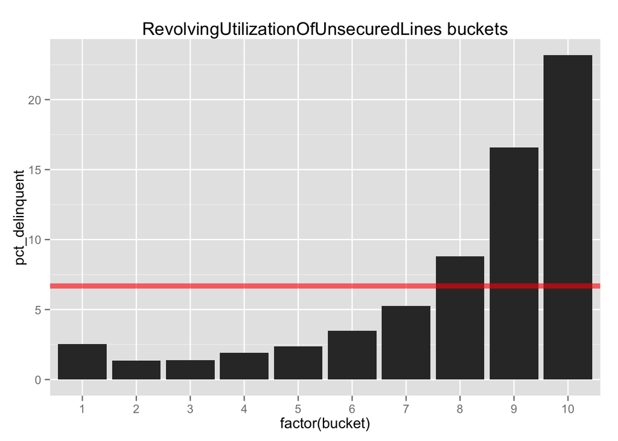

```r
########################################
#  RevolvingUtilizationOfUnsecuredLines
########################################

# generated with gen_feature_bucket_r.py

# split into ten groups based on age
num_buckets <- 10
bucket <- seq(1, num_buckets)
ar <- rank(cs$RevolvingUtilizationOfUnsecuredLines, ties.method = "first")
decile <- cut(ar, quantile(ar, probs=0:10/10), include.lowest=TRUE, labels=FALSE)
deciles_RevolvingUtilizationOfUnsecuredLines <- split(cs, decile)
pct_delinquent <- vector("numeric", length(deciles_RevolvingUtilizationOfUnsecuredLines))
for (i in seq_along(deciles_RevolvingUtilizationOfUnsecuredLines)){
  pct_delinquent[i] <- 100 * mean(deciles_RevolvingUtilizationOfUnsecuredLines[[i]]$SeriousDlqin2yrs)
}
# results
D9 <- data.frame(pct_delinquent, bucket)
# str(D9)
p9 <- ggplot(data = D9, aes(x = factor(bucket), y = pct_delinquent)) +
  geom_bar(stat ="identity")  +
  geom_hline(aes (yintercept = 100 * sample_avg), alpha = 6/10, color = 'red', linetype = 1, lwd = 2) +
  ggtitle("RevolvingUtilizationOfUnsecuredLines buckets")
p9
```

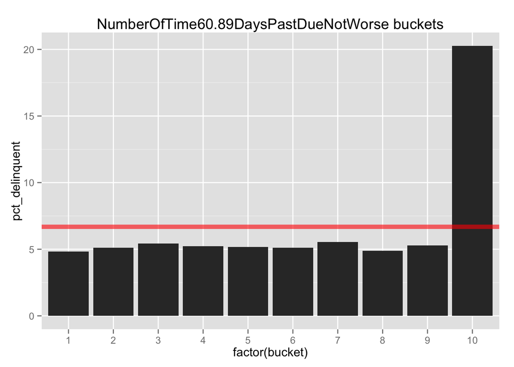

```r
########################################
#  NumberOfTime60.89DaysPastDueNotWorse
########################################

# generated with gen_feature_bucket_r.py

# split into ten groups based on age
num_buckets <- 10
bucket <- seq(1, num_buckets)
ar <- rank(cs$NumberOfTime60.89DaysPastDueNotWorse, ties.method = "first")
decile <- cut(ar, quantile(ar, probs=0:10/10), include.lowest=TRUE, labels=FALSE)
deciles_NumberOfTime60.89DaysPastDueNotWorse <- split(cs, decile)
pct_delinquent <- vector("numeric", length(deciles_NumberOfTime60.89DaysPastDueNotWorse))
for (i in seq_along(deciles_NumberOfTime60.89DaysPastDueNotWorse)){
  pct_delinquent[i] <- 100 * mean(deciles_NumberOfTime60.89DaysPastDueNotWorse[[i]]$SeriousDlqin2yrs)
}
# results
D10 <- data.frame(pct_delinquent, bucket)
# str(D10)
p10 <- ggplot(data = D10, aes(x = factor(bucket), y = pct_delinquent)) +
  geom_bar(stat ="identity")  +
  geom_hline(aes (yintercept = 100 * sample_avg), alpha = 6/10, color = 'red', linetype = 1, lwd = 2) +
  ggtitle("NumberOfTime60.89DaysPastDueNotWorse buckets")
p10
```

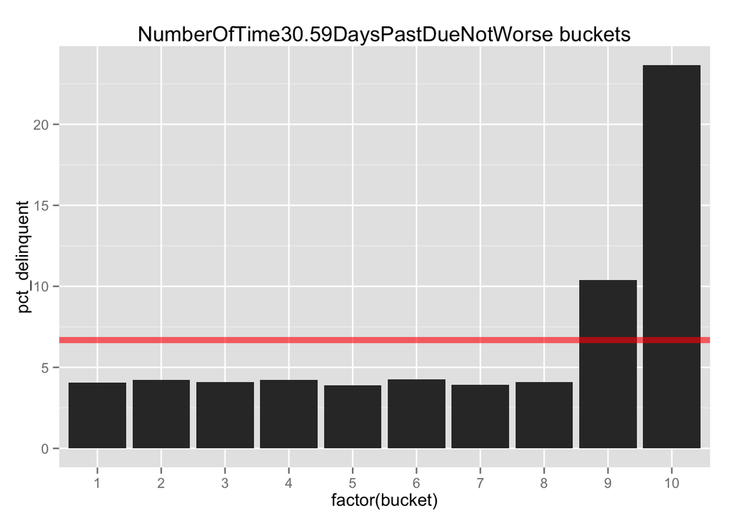

```r
########################################
#  NumberOfTime30.59DaysPastDueNotWorse
########################################

# generated with gen_feature_bucket_r.py

# split into ten groups based on age
num_buckets <- 10
bucket <- seq(1, num_buckets)
ar <- rank(cs$NumberOfTime30.59DaysPastDueNotWorse, ties.method = "first")
decile <- cut(ar, quantile(ar, probs=0:10/10), include.lowest=TRUE, labels=FALSE)
deciles_NumberOfTime30.59DaysPastDueNotWorse <- split(cs, decile)
pct_delinquent <- vector("numeric", length(deciles_NumberOfTime30.59DaysPastDueNotWorse))
for (i in seq_along(deciles_NumberOfTime30.59DaysPastDueNotWorse)){
  pct_delinquent[i] <- 100 * mean(deciles_NumberOfTime30.59DaysPastDueNotWorse[[i]]$SeriousDlqin2yrs)
}
# results
D11 <- data.frame(pct_delinquent, bucket)
# str(D11)
p11 <- ggplot(data = D11, aes(x = factor(bucket), y = pct_delinquent)) +
  geom_bar(stat ="identity")  +
  geom_hline(aes (yintercept = 100 * sample_avg), alpha = 6/10, color = 'red', linetype = 1, lwd = 2) +
  ggtitle("NumberOfTime30.59DaysPastDueNotWorse buckets")
p11
```

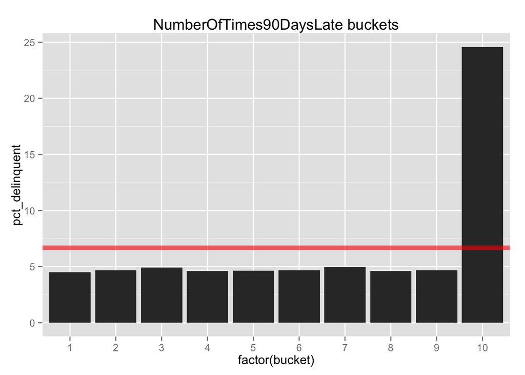

```r
########################################
#  NumberOfTimes90DaysLate
########################################

# generated with gen_feature_bucket_r.py

# split into ten groups based on age
num_buckets <- 10
bucket <- seq(1, num_buckets)
ar <- rank(cs$NumberOfTimes90DaysLate, ties.method = "first")
decile <- cut(ar, quantile(ar, probs=0:10/10), include.lowest=TRUE, labels=FALSE)
deciles_NumberOfTimes90DaysLate <- split(cs, decile)
pct_delinquent <- vector("numeric", length(deciles_NumberOfTimes90DaysLate))
for (i in seq_along(deciles_NumberOfTimes90DaysLate)){
  pct_delinquent[i] <- 100 * mean(deciles_NumberOfTimes90DaysLate[[i]]$SeriousDlqin2yrs)
}
# results
D12 <- data.frame(pct_delinquent, bucket)
# str(D12)
p12 <- ggplot(data = D12, aes(x = factor(bucket), y = pct_delinquent)) +
  geom_bar(stat ="identity")  +
  geom_hline(aes (yintercept = 100 * sample_avg), alpha = 6/10, color = 'red', linetype = 1, lwd = 2) +
  ggtitle("NumberOfTimes90DaysLate buckets")
p12
```

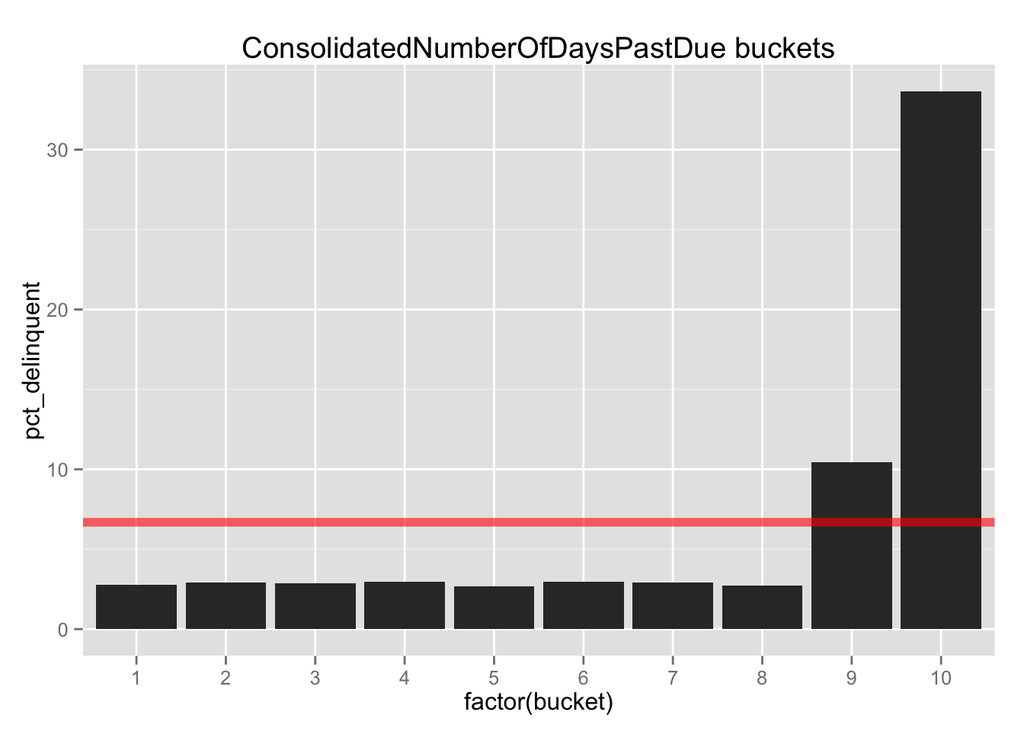

```r
########################################
#  ConsolidatedNumberOfDaysPastDue
########################################

# generated with gen_feature_bucket_r.py

# split into ten groups based on age
num_buckets <- 10
bucket <- seq(1, num_buckets)
ar <- rank(cs$ConsolidatedNumberOfDaysPastDue, ties.method = "first")
decile <- cut(ar, quantile(ar, probs=0:10/10), include.lowest=TRUE, labels=FALSE)
deciles_ConsolidatedNumberOfDaysPastDue <- split(cs, decile)
pct_delinquent <- vector("numeric", length(deciles_ConsolidatedNumberOfDaysPastDue))
for (i in seq_along(deciles_ConsolidatedNumberOfDaysPastDue)){
  pct_delinquent[i] <- 100 * mean(deciles_ConsolidatedNumberOfDaysPastDue[[i]]$SeriousDlqin2yrs)
}
# results
D13 <- data.frame(pct_delinquent, bucket)
# str(D13)
p13 <- ggplot(data = D13, aes(x = factor(bucket), y = pct_delinquent)) +
  geom_bar(stat ="identity")  +
  geom_hline(aes (yintercept = 100 * sample_avg), alpha = 6/10, color = 'red', linetype = 1, lwd = 2) +
  ggtitle("ConsolidatedNumberOfDaysPastDue buckets")
p13
```

```r
# group charts into one
png("feature_bucketed_discr.png", width=12, height=16, units="in", res=100)
grid.arrange( p1, p2, p3, p4, p5, p6, p7, p8, p9, p10, p11, p12, p13,  ncol = 3)
dev.off()
```